# BRD: Exploratory analysis

Société Générale - IBFS/MKG

25/01/2017

[figure not shown]

# 1 Introduction

Exploratory Data Analysis or EDA is an imporant phase in the Data Science pipeline, with a purpose of exploring the data to examine the structure of the dataset/s, distribution of its variables and their respective relationships.

Statistitians, since John Tukey - who first championed its usage - have relied on EDA prior to the formal modeling phase because the graphical display of the data enables a fast confirmation or rejection of the underling assumtions, detection of unknown patterns and selection of the appropriate models.

In respect to churn, given that the analysis represents a binary classification (churner or non churner) problem, the best practice approach in both academia and our experience is to preform a comparative statistics in the exploratory phase. In particular, we will compare the distriution of each variable for clients previouslly identified as either churner or non churner.

# 2 Client Database: Analysis

Based on the initial data audit, our previous experience in churn analysis and information provided by BRD, we decised to treat the data in broader groups/categories of tables with similar characteristics. We also assigned them different priority levels in the treatment of the data - 1 (highest) to 3 (lowest).

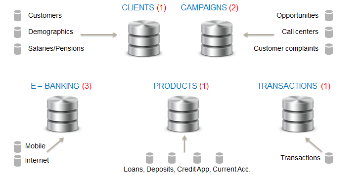

The Client Mash database contains the: **Customer, Demographics and Salaries/Pensions/Conventions** tables in our definition.

We know their original names from a file provided by BRD. But nevertheless, we must first locate them in the HDFS and check their size and file type.

```r
#Load libraries
library(data.table)
library(dplyr)
library(lubridate)
library(reshape2)

detach("package:rmr2", unload=TRUE)


library(bit64)
library(rhdfs)
library(tidyr)
library(ggplot2)

#Initialize HDFS
hdfs.init()

#List files in HDFS directory
hdfslist.files("/lab/ibfs/sdm/BRD")
```

```
##    permission    owner  group        size          modtime
## 1  -rwxr-x--- sdmmpadm gm_sdm     1112729 2016-11-28 17:29
## 2  drwxr-x--- sdmmpadm gm_sdm           0 2017-02-03 18:43
## 3  -rw-r--r--  A454638 gm_sdm  3192266698 2017-02-03 19:39
## 4  -rwxr-x--- sdmmpadm gm_sdm 37998808328 2016-11-28 17:33
## 5  -rwxr-x--- sdmmpadm gm_sdm  1580796861 2016-11-28 17:36
## 6  -rwxr-x--- sdmmpadm gm_sdm    43535771 2016-11-28 17:33
## 7  -rwxr-x--- sdmmpadm gm_sdm  6983951965 2016-11-28 17:34
## 8  -rwxr-x--- sdmmpadm gm_sdm  2740201448 2016-11-28 17:34
## 9  -rwxr-x--- sdmmpadm gm_sdm 11698686189 2016-11-28 17:35
## 10 -rwxr-x--- sdmmpadm gm_sdm  1070557911 2016-11-28 17:36
## 11 -rwxr-x--- sdmmpadm gm_sdm   786164470 2016-11-28 17:36
## 12 -rwxr-x--- sdmmpadm gm_sdm   203677220 2016-11-28 17:36
## 13 -rwxr-x--- sdmmpadm gm_sdm   207414700 2016-11-28 17:36
## 14 -rwxr-x--- sdmmpadm gm_sdm  7864129895 2016-11-28 17:37
```

[output cut: 17 more lines]

We can see that the respective files are csv’s of **relatively large size**.

- Client demographics - ibfsdemografice_f.csv - 11GB
- Client information - ibfsclienti_f.csv - 6.9 GB
- Client salaries/pension/conventions - ibfs_histconventii_f - 1.5 GB

The reason they are so large is because the **data BRD provided contains combined snapshots of their database at monthly reporting dates**. This is very useful because *we can track changes in the client behavior through multiple dimensions*. However, we must be very careful because R, in general, is designed to work in memory and that limits the size of files it can process with the RAM resourses we posses in our hardware. Fortenately, we are utiling a R Studio Server edition with 300 Gb in RAM memory, so the size shouldn’t be a problem.

In case the data is too big for your hardware resources, there are few solutions:

- Rent PaaS such as [AWS](https://aws.amazon.com/ec2/spot/) - cheap solution, but there might be issues with complience
- Process the data chunk - wise - a library that enables this in R is “chunked”
- Process the data in distributed setting - Spark API`s for R are [SparkR](http://spark.apache.org/docs/latest/sparkr.html) and [SparklyR](http://spark.rstudio.com/)

In our experience however, *should the problem be specified correctly and the steps towards its solution be optimized carefully, very often the problems that appear to require distributed computing can be actually sovled on a single machine*. In that sense, if possible, distibuted computing is best to be avoided because it adds additional layer of complexity in multiple ways.

## 2.1 Pre-Process Data

As a result, we will **first pre - process the datasets seperately** to obtain the last snapshot of each client within the data, and than during the feature engineering phase we will create indicators that track the changes in the client behavior.

### 2.1.1 Demographic Data

```r
#Get and load demographic data from HDFS
hdfs.get(src = "/lab/ibfs/sdm/BRD/ibfsdemografice_f.csv", dest = "./")
data <- fread("./ibfsdemografice_f.csv")

#Add column names
colnames(data)[1] <- 'customer_type'
colnames(data)[2] <- 'branch_id'
colnames(data)[3] <- 'open_date_customer'
colnames(data)[4] <- 'customer_id'
colnames(data)[5] <- 'birthdate'
colnames(data)[6] <- 'customer_type_individuals'
colnames(data)[7] <- 'branch_id_managed'
colnames(data)[8] <- 'gender'
colnames(data)[9] <- 'employment_type'
colnames(data)[10] <- 'occupation'
colnames(data)[11] <- 'vip_flag'
colnames(data)[12] <- 'deceased_date'
colnames(data)[13] <- 'number_of_kids'
colnames(data)[14] <- 'education'
colnames(data)[15] <- 'marital_status'
colnames(data)[16] <- 'marketing_segment_code'
colnames(data)[17] <- 'reporting_date'

#Convert reporting date variable to POSIXct format
data$reporting_date <- as.Date(data$reporting_date, "%d%b%Y")

# Take last snapshot of the data from the last reporting date of each client
unique_clients_demographics_full <- data %>%
  group_by(customer_id) %>%
  filter(reporting_date == max(reporting_date)) %>%
  filter(1:n() == 1)

# Write output to home directory
write.csv(unique_clients_demographics_full, "unique_clients_demographics_full.csv")
```

### 2.1.2 Client information Data

```r
#Get and load client information data from HDFS
hdfs.get(src = "/lab/ibfs/sdm/BRD/ibfsclienti_f.csv", dest = "./")
data <- fread("./ibfsclienti_f.csv")

#Add column names
colnames(data)[1] <- 'customer_id'
colnames(data)[2] <- 'branch_open'
colnames(data)[3] <- 'customer_status'
colnames(data)[4] <- 'customer_type'
colnames(data)[5] <- 'marketing_segment_code'
colnames(data)[6] <- 'equipment_rate'
colnames(data)[7] <- 'branch_manage'
colnames(data)[8] <- 'flag_staff'
colnames(data)[9] <- 'open_date'
colnames(data)[10] <- 'reporting_date'

#Convert reporting date variable to POSIXct format
data$reporting_date <- as.Date(data$reporting_date, "%d%b%Y")

# Take last snapshot of the demographic data from last
unique_clients_full <- data %>%
  group_by(customer_id) %>%
  filter(reporting_date == max(reporting_date)) %>%
  filter(1:n() == 1)

# Write output to home directory
write.csv(unique_clients_full, "unique_clients_full.csv")
```

### 2.1.3 Convention Data

```r
#Get and load demographic data from HDFS
hdfs.get(src = "/lab/ibfs/sdm/BRD/ibfs_histconventii_f.csv", dest = "./")
data <- fread("./ibfs_histconventii_f.csv")

#Add column names
colnames(data)[1] <- 'customer_id'
colnames(data)[2] <- 'technical_field'
colnames(data)[3] <- 'salary_convention_flag'
colnames(data)[4] <- 'pension_convention_flag'
colnames(data)[5] <- 'student_allocation_convention_flag'
colnames(data)[6] <- 'other_convention_flag'
colnames(data)[7] <- 'sum_incomes'
colnames(data)[8] <- 'reporting_date_technical'
colnames(data)[9] <- 'reporting_date'

#Convert reporting date variable to POSIXct format
data$reporting_date <- as.Date(data$reporting_date, "%d%b%Y")

# Take last snapshot of the data from the last reporting date of each client
salary_and_pension_unique <- data %>%
  group_by(customer_id) %>%
  filter(reporting_date == max(reporting_date)) %>%
  filter(1:n() == 1)

# Write output to home directory
write.csv(salary_and_pension_unique, "salary_and_pension_unique.csv")
```

### 2.1.4 Merge Data

```r
individual_data  <- fread("./unique_clients_full.csv", drop = 1)
demographic_data <- fread("./unique_clients_demographics_full.csv", drop = 1)
salary_pension_data <- fread("./salary_and_pension_unique.csv", drop = 1)

#Merge datasets
last_image <- individual_data %>%
  merge(demographic_data , by = c("customer_id"), all.x = TRUE) %>%
  merge(salary_pension_data , by = c("customer_id"), all.x = TRUE)

#Change strings to dates
last_image$open_date <- dmy(last_image$open_date)
last_image$open_date_customer <- dmy(last_image$open_date_customer)
last_image$birthdate <- dmy(last_image$birthdate)
last_image$reporting_date_technical <- dmy(last_image$reporting_date_technical)

write.csv(last_image, "client_data.csv")
```

## 2.2 Comparative Statistics

Once we have created a processed dataset we can utilze myriad of methods and tools to explore the data.

Initially, we provided BRD a Power Point presentation that was mainly consisted of plots created in Excel. The method utized to explore the data with this aproach is described below. **The benefits** in utilzing spreadsheet applications is that the analysis is in a sense *closer to non - technical people*. However, the **side efects** are that the created plots are inherently *static, constrained by the format of the presentation and slow to develop*.

In the second part of the comparative statistics, we will show how we can utilze the power of R as a programming language to extend the capabilities of Excel. The **benefits of R** (also applicable to python, scala, julia and other languages) are that *plots that take manual work in Excel can be created by a single function call*. Furthermore, libraries such as ggplot2 enable us to preform *multi-dimensional analysis (ex. age and education comparison for two groups) and exploit population templates* (The Economist, WSJ, etc), while others such as ggvis to *plot geo-spaial data*. We can use specialised libraries such as caret to look out for *initial signns of discriminative behavior* for the purposes of a machine learning analysis and Shiny to create *interactive plots*. Some R examples can be seen [here,](http://www.r-graph-gallery.com/) [here and](http://www.showmeshiny.com/) [here.](http://www.htmlwidgets.org/showcase_leaflet.html)

Other tools that could potentially be used range from data visualization platforms such as Tableau, full - stack analytics toolkits by providers such as Palantir or advanced CRM systems such as Salesforce and Oracle.

### 2.2.1 Spreedsheet analysis

The code below is supposed to *create seperate csv files for each variable in the processed client dataset with nominal and proportional repartition per churners and non churners*.

Firt, we create a new directory so that we don’t overflow the existing home directory with a lot of files.

```r
#Create directory to export the csv files
dirctoryName <- "Results: Client DB - Comparative Statistics" #Name the folder of the output result
if(!file.exists(dirctoryName)) { dir.create(dirctoryName) }
currentDirectory = getwd()
setwd(paste(currentDirectory ,dirctoryName,sep="/"))
```

Than we load in memory the processed client dataset and churner indicator.

```r
client_data <- fread("~/client_data_old.csv", drop = 1)
churn_indicator <- fread("~/churner_indicator_new.csv", drop = 1)
```

Since the churner indicator is contained in a separate file, *we need to merge the two dataframes*. We do this with a left_join, which esentially means feed all fields in the churn_indicator dataframe of the variable customer_id that match in the same variable within the client_data dataframe.

```r
client_mash_database <- merge(churn_indicator, client_data, by = "customer_id", all.x = TRUE)
```

If we check the number of rows, prior and post merge, we’ll see that the combined datframe has the same number of rows as the churn indicator - which was obviouslly our goal.

```r
#Number of rows in the Churn Indicator dataframe
nrow(churn_indicator)
```

```
## [1] 1665176
```

```r
#Number of rows in the initial client data dataframe
nrow(client_data)
```

```
## [1] 6683070
```

```r
#Number of rows in the combined dataframe
nrow(client_mash_database)
```

```
## [1] 1665176
```

Finally, we run a customer made function we created to do the repartition as per churner vs. non - churner clients.

The function will test the *frequency of the occurencies per specified variable*.

```r
# Creates csv files for specified columns/variables, testing frequency of occurencies per specified variable.

aggregate_per_group <- function(column) {
  client_mash_database %>%
    group_by_(column, "is_churner")  %>%
    summarise(Unique_Elements = n()) %>%
    dcast(data = ., paste(column,  '~ is_churner'),
          value.var="Unique_Elements", fill = 0) -> print
  write.csv(print, file=paste(column,".csv",sep="_"))
}


#We call the function will the command below
aggregate_per_group("gender")
```

The code above is *suitable to check a select few of the variable from the dataframe*. However, given that we have 35 variable, we want to *automate the work*. In that sense, the lapply function, which is a R specific type of loop, will do the work for us.

```r
#Run the function for all variables.
lapply(names(client_mash_database), aggregate_per_group)

#Run the function for a subset of variables.
lapply(names(client_mash_database)[-c(1, 2, 3)], aggregate_per_group)
```

The rest of the analysis is than conducted in Excel or some other spreadsheet application.

### 2.2.2 Interactive R analysis

As we said previouslly, some fine - tuning of the data needs to be done before we can plot it in a visually effective way.

In that sense, let`s check the structure of the client data once more.

```r
str(client_mash_database)
```

```
## Classes 'data.table' and 'data.frame':   1665176 obs. of  35 variables:
##  $ customer_id                       :Class 'integer64'  num [1:1665176] 4.94e-310 4.94e-310 4.94e-310 4.94e-310 4.94e-310 ...
##  $ is_churner                        : int  0 0 1 0 0 0 0 0 0 0 ...
##  $ branch_open                       : int  2400 4000 3300 2700 4100 100 4000 800 200 400 ...
##  $ customer_status                   : int  1 1 2 1 1 1 1 1 1 1 ...
##  $ customer_type.x                   : logi  FALSE FALSE FALSE FALSE FALSE FALSE ...
##  $ marketing_segment_code.x          : int  1 1 1 1 1 1 1 1 1 1 ...
##  $ equipment_rate                    : int  4 3 NA 3 6 7 2 3 4 2 ...
##  $ branch_manage                     : int  2380 4040 8860 9750 5110 110 6650 4850 200 8930 ...
##  $ flag_staff                        : int  0 0 0 0 0 0 0 0 0 0 ...
##  $ open_date                         : chr  "2012-01-26" "2007-02-13" "2006-02-24" "2015-07-27" ...
##  $ reporting_date.x                  : chr  "2016-08-31" "2016-08-31" "2016-08-31" "2016-08-31" ...
##  $ customer_type.y                   : chr  "A" "A" "A" "A" ...
##  $ branch_id                         : int  2400 4000 3300 2700 4100 100 4000 800 200 400 ...
##  $ open_date_customer                : chr  "2012-01-26" "2007-02-13" "2006-02-24" "2015-07-27" ...
```

[output cut: 23 more lines]

First, we can see that during the merging of the three tables (client information, demographics and salary/pension/conventions) some of the variables that have been duplicated. This shouldn`t be the case, as they represent the same data, so we will remove them.

```r
client_mash_database <- select(client_mash_database, -open_date, -marketing_segment_code.y, -reporting_date.x, -reporting_date.y, -reporting_date_technical, -branch_id)
```

In addition, we will convert the date variables to the proper POSIXct format.

When we are dealing with date variables, we can also calculate some meta-variables. For instance, if we substract the date of birth from the reference date or the client entry date, **we obtain the age and seniority**, respectivly.

```r
client_mash_database$open_date_customer <- ymd(client_mash_database$open_date_customer)
client_mash_database$birthdate <- ymd(client_mash_database$birthdate)
```

```r
date_ref <- ymd("2016-02-29")

client_mash_database <- mutate(client_mash_database, age = year(date_ref) - year(birthdate))
client_mash_database <- mutate(client_mash_database, seniority = year(date_ref) - year(open_date_customer)) #seniority in years


client_mash_database <- mutate(client_mash_database, seniority_months = (date_ref - open_date_customer)/2629800)
client_mash_database$seniority_months <- floor(client_mash_database$seniority_months) #seniority in months
```

If we see the range of BRD`s clients age however, we will see that the values are quite wide. Since we can assume that in the discriminative behavior, the year - to - year differece in the age is not so important, we can group the ages into categories.

```r
setDT(client_mash_database)
    client_mash_database[age <20, agegroup := "0-19"]
    client_mash_database[age >19 & age <25, agegroup := "20-24"]
    client_mash_database[age >24 & age <30, agegroup := "25-29"]
    client_mash_database[age >29 & age <35, agegroup := "30-34"]
    client_mash_database[age >34 & age <40, agegroup := "35-39"]
    client_mash_database[age >39 & age <45, agegroup := "40-44"]
    client_mash_database[age >44 & age <50, agegroup := "45-49"]
    client_mash_database[age >49 & age <55, agegroup := "50-54"]
    client_mash_database[age >54 & age <60, agegroup := "55-59"]
    client_mash_database[age >59 & age <65, agegroup := "60-64"]
    client_mash_database[age >64 & age <70, agegroup := "65-69"]
    client_mash_database[age >69 & age <75, agegroup := "70-74"]
    client_mash_database[age >74 & age <80, agegroup := "75-79"]
    client_mash_database[age >79 & age <85, agegroup := "80-84"]
    client_mash_database[age >84, agegroup := "85+"]
```

Furthermore, from the structure function we noticed two more things.

First, multiple variables contain NA fields, even when this is incorrect. For example, the absence of value in the convention flags or equipment rate means a value of zero.

Second, most of the categorical variables are encoded with acronyms. For instance, in the education variable - HSD represents High School degree.

We need to fix both of these situations prior to any plotting.

```r
#First we change the categorical variables to strings
client_mash_database$customer_status <- as.character(client_mash_database$customer_status)
client_mash_database$marketing_segment_code.x <- as.character(client_mash_database$marketing_segment_code.x)
client_mash_database$occupation <- as.character(client_mash_database$occupation)
```

```r
client_mash_database$salary_convention_flag[is.na(client_mash_database$salary_convention_flag)] <-0
client_mash_database$pension_convention_flag[is.na(client_mash_database$pension_convention_flag)] <-0
client_mash_database$student_allocation_convention_flag[is.na(client_mash_database$student_allocation_convention_flag)] <-0
client_mash_database$other_convention_flag[is.na(client_mash_database$other_convention_flag)] <-0
client_mash_database$sum_incomes[is.na(client_mash_database$sum_incomes)] <-0
client_mash_database$equipment_rate[is.na(client_mash_database$equipment_rate)] <-0

 #we load the plyr library only temporarily because it conflicts with dplyr

library(plyr)
client_mash_database$customer_status <-
            revalue(client_mash_database$customer_status,
                    c("0"="Other status", "1"="Active customers", "2"="Fictive customers",
                      "3"="Inactive customers", "4" = "Representative customers"))

client_mash_database$employment_type <-
            revalue(client_mash_database$employment_type,
                    c("AG"="Agriculture", "BO"="Business owner", "EM"="Employee_EM", "IN"="Independent",
                      "NI" = "without payroll", "SA" = "Employee_SA"))

client_mash_database$marketing_segment_code.x <-
            revalue(client_mash_database$marketing_segment_code.x,
                    c("1"="Mass Customers", "2"="Mass Customers with potential", "3"="Affluent", "4"="Other",
                      "0" = "NA"))

client_mash_database$occupation <-
            revalue(client_mash_database$occupation,
                    c("1"="CRP", "2"="Special Occupation", "3"="Technical",
                      "4"="Public Sector", "5" = "Services/Trade",
                      "6" = "Agriculture", "7" = "Not qualified",
                      "8" = "Pensioners", "9" = "Students", "10" = "Students",
                      "11" = "Without occupation", "12" = "Unemployed",
                      "13" = "Business owner employees", "14" = "Business owner manager/director"))

client_mash_database$education <-
            revalue(client_mash_database$education,
                    c("GMN"="Gymnasium", "HSD"="High School", "PRF"="Professional",
                      "PWS"="Primary or without studies", "UNV" = "University", "N" = "Not available"))

client_mash_database$marital_status <-
            revalue(client_mash_database$marital_status,
                    c("D"="Divorced", "M"="Married", "S"="Single",
                      "U"="Unknown", "W" = "Widow"))

 #We detach plyr because it creates conflicts with the dplyr package
detach("package:plyr", unload=TRUE)
```

Finally, we were additionally provided by BRD with a file matching the branch where the clients are managed with the respective region. This enables us to see different dimension of the churning behavior, when we plot the variables geographically.

```r
branch <- fread("./branch_region_name.csv")

brd_labels <- select(branch, C_UNIT, NAME_1)
client_location <- select(client_mash_database, customer_id, branch_manage)

colnames(brd_labels)[1] <- "branch_manage"
colnames(brd_labels)[2] <- "region"
brd_labels_clean <-brd_labels[!duplicated(brd_labels$branch_manage),]

clients_labeled <- merge(client_location, brd_labels_clean, by = "branch_manage", all.x = TRUE)
row.names(clients_labeled) <- NULL
clients_labeled <- select(clients_labeled, customer_id, region)
client_mash_database <- merge(client_mash_database, clients_labeled, by = "customer_id", all.x = TRUE)
```

Finally, we can move on with the plotting of the categorical variables.

One of the major strengths of R are its visualisation libraries. In this case, we will use ggplot2, which is based on the principles of [Grammar of Graphics - link](https://www.amazon.com/Grammar-Graphics-Statistics-Computing/dp/0387245448)

```r
library(dplyr)
library(tidyr)

test <-client_mash_database %>%
  group_by(is_churner, agegroup)  %>%
  summarise(count = n()) %>%
  dcast(agegroup ~ is_churner, value.var="count")

colnames(test)[2] <- "non_churner"
colnames(test)[3] <- "churner"

test <- na.omit(test)
test$churner <- (test$churner / sum(test$churner)) * 100
test$non_churner <- (test$non_churner / sum(test$non_churner)) * 100

test$churner <- round(test$churner,digits=1)
test$non_churner <- round(test$non_churner,digits=1)

test2 <- gather(test, churner, non_churner, -agegroup)

age <- ggplot(test2, aes(agegroup, non_churner, fill = churner)) +
       geom_bar(position="dodge",stat="identity") +
       scale_fill_brewer(palette = "Set1") +
       ylab("Percent %") +
       xlab("") +
       coord_flip() +
       theme(legend.title=element_blank()) +
       ggtitle("Age group") +
       theme(plot.title = element_text(face="italic"))
```

Furthermore, we are going to utilze the function below to create a **calendar heatmap**.

Calendar heatmaps, as heatmaps in a broader sense, are used to *display the frequency of distribution across different dates*. In specific, the function below will enable us to track that dimension of the date, for different variables, along: days of a week, weeks of a month, months and years.

```r
calendarHeat <- function(dates,
                         values,
                         ncolors=99,
                         color="r2g",
                         varname="Values",
                         date.form = "%d/%m/%Y", ...) {
  require(lattice)
  require(grid)
  require(chron)
  if (class(dates) == "character" | class(dates) == "factor" ) {
    dates <- strptime(dates, date.form)
  }
  caldat <- data.frame(value = values, dates = dates)
  min.date <- as.Date(paste(format(min(dates), "%Y"),
                            "-1-1",sep = ""))
  max.date <- as.Date(paste(format(max(dates), "%Y"),
                            "-12-31", sep = ""))
  dates.f <- data.frame(date.seq = seq(min.date, max.date, by="days"))

  # Merge moves data by one day, avoid
  caldat <- data.frame(date.seq = seq(min.date, max.date, by="days"), value = NA)
  dates <- as.Date(dates)
  caldat$value[match(dates, caldat$date.seq)] <- values

  caldat$dotw <- as.numeric(format(caldat$date.seq, "%w"))
  caldat$woty <- as.numeric(format(caldat$date.seq, "%U")) + 1
  caldat$yr <- as.factor(format(caldat$date.seq, "%Y"))
  caldat$month <- as.numeric(format(caldat$date.seq, "%m"))
  yrs <- as.character(unique(caldat$yr))
  d.loc <- as.numeric()
  for (m in min(yrs):max(yrs)) {
    d.subset <- which(caldat$yr == m)
    sub.seq <- seq(1,length(d.subset))
    d.loc <- c(d.loc, sub.seq)
  }
  caldat <- cbind(caldat, seq=d.loc)

  #color styles
  r2b <- c("#0571B0", "#92C5DE", "#F4A582", "#CA0020") #red to blue
  r2g <- c("#D61818","#f07b35", "#66ee96", "#55b44f")   #red to green
  w2b <- c("#045A8D", "#2B8CBE", "#74A9CF", "#BDC9E1", "#F1EEF6")   #white to blue

  assign("col.sty", get(color))
  calendar.pal <- colorRampPalette((col.sty), space = "Lab")
  def.theme <- lattice.getOption("default.theme")
  cal.theme <-
    function() {
      theme <-
        list(
          strip.background = list(col = "transparent"),
          strip.border = list(col = "transparent"),
          axis.line = list(col="transparent"),
          par.strip.text=list(cex=0.8))
    }
  lattice.options(default.theme = cal.theme)
  yrs <- (unique(caldat$yr))
  nyr <- length(yrs)
  print(cal.plot <- levelplot(value~woty*dotw | yr, data=caldat,
                              as.table=TRUE,
                              aspect=.12,
                              layout = c(1, nyr%%7),
                              between = list(x=0, y=c(1,1)),
                              strip=TRUE,
                              main = paste("Calendar Heat Map of ", varname, sep = ""),
                              scales = list(
                                x = list(
                                  at= c(seq(2.9, 52, by=4.42)),
                                  labels = month.abb,
                                  alternating = c(1, rep(0, (nyr-1))),
                                  tck=0,
                                  cex = 0.7),
                                y=list(
                                  at = c(0, 1, 2, 3, 4, 5, 6),
                                  labels = c("Sunday", "Monday", "Tuesday", "Wednesday", "Thursday",
                                             "Friday", "Saturday"),
                                  alternating = 1,
                                  cex = 0.6,
                                  tck=0)),
                              xlim =c(0.4, 54.6),
                              ylim=c(6.6,-0.6),
                              cuts= ncolors - 1,
                              col.regions = (calendar.pal(ncolors)),
                              xlab="" ,
                              ylab="",
                              colorkey= list(col = calendar.pal(ncolors), width = 0.6, height = 0.5),
                              subscripts=TRUE
  ) )
  panel.locs <- trellis.currentLayout()
  for (row in 1:nrow(panel.locs)) {
    for (column in 1:ncol(panel.locs))  {
      if (panel.locs[row, column] > 0)
      {
        trellis.focus("panel", row = row, column = column,
                      highlight = FALSE)
        xyetc <- trellis.panelArgs()
        subs <- caldat[xyetc$subscripts,]
        dates.fsubs <- caldat[caldat$yr == unique(subs$yr),]
        y.start <- dates.fsubs$dotw[1]
        y.end   <- dates.fsubs$dotw[nrow(dates.fsubs)]
        dates.len <- nrow(dates.fsubs)
        adj.start <- dates.fsubs$woty[1]

        for (k in 0:6) {
          if (k < y.start) {
            x.start <- adj.start + 0.5
          } else {
            x.start <- adj.start - 0.5
          }
          if (k > y.end) {
            x.finis <- dates.fsubs$woty[nrow(dates.fsubs)] - 0.5
          } else {
            x.finis <- dates.fsubs$woty[nrow(dates.fsubs)] + 0.5
          }
          grid.lines(x = c(x.start, x.finis), y = c(k -0.5, k - 0.5),
                     default.units = "native", gp=gpar(col = "grey", lwd = 1))
        }
        if (adj.start <  2) {
          grid.lines(x = c( 0.5,  0.5), y = c(6.5, y.start-0.5),
                     default.units = "native", gp=gpar(col = "grey", lwd = 1))
          grid.lines(x = c(1.5, 1.5), y = c(6.5, -0.5), default.units = "native",
                     gp=gpar(col = "grey", lwd = 1))
          grid.lines(x = c(x.finis, x.finis),
                     y = c(dates.fsubs$dotw[dates.len] -0.5, -0.5), default.units = "native",
                     gp=gpar(col = "grey", lwd = 1))
          if (dates.fsubs$dotw[dates.len] != 6) {
            grid.lines(x = c(x.finis + 1, x.finis + 1),
                       y = c(dates.fsubs$dotw[dates.len] -0.5, -0.5), default.units = "native",
                       gp=gpar(col = "grey", lwd = 1))
          }
          grid.lines(x = c(x.finis, x.finis),
                     y = c(dates.fsubs$dotw[dates.len] -0.5, -0.5), default.units = "native",
                     gp=gpar(col = "grey", lwd = 1))
        }
        for (n in 1:51) {
          grid.lines(x = c(n + 1.5, n + 1.5),
                     y = c(-0.5, 6.5), default.units = "native", gp=gpar(col = "grey", lwd = 1))
        }
        x.start <- adj.start - 0.5

        if (y.start > 0) {
          grid.lines(x = c(x.start, x.start + 1),
                     y = c(y.start - 0.5, y.start -  0.5), default.units = "native",
                     gp=gpar(col = "black", lwd = 1.75))
          grid.lines(x = c(x.start + 1, x.start + 1),
                     y = c(y.start - 0.5 , -0.5), default.units = "native",
                     gp=gpar(col = "black", lwd = 1.75))
          grid.lines(x = c(x.start, x.start),
                     y = c(y.start - 0.5, 6.5), default.units = "native",
                     gp=gpar(col = "black", lwd = 1.75))
          if (y.end < 6  ) {
            grid.lines(x = c(x.start + 1, x.finis + 1),
                       y = c(-0.5, -0.5), default.units = "native",
                       gp=gpar(col = "black", lwd = 1.75))
            grid.lines(x = c(x.start, x.finis),
                       y = c(6.5, 6.5), default.units = "native",
                       gp=gpar(col = "black", lwd = 1.75))
          } else {
            grid.lines(x = c(x.start + 1, x.finis),
                       y = c(-0.5, -0.5), default.units = "native",
                       gp=gpar(col = "black", lwd = 1.75))
            grid.lines(x = c(x.start, x.finis),
                       y = c(6.5, 6.5), default.units = "native",
                       gp=gpar(col = "black", lwd = 1.75))
          }
        } else {
          grid.lines(x = c(x.start, x.start),
                     y = c( - 0.5, 6.5), default.units = "native",
                     gp=gpar(col = "black", lwd = 1.75))
        }

        if (y.start == 0 ) {
          if (y.end < 6  ) {
            grid.lines(x = c(x.start, x.finis + 1),
                       y = c(-0.5, -0.5), default.units = "native",
                       gp=gpar(col = "black", lwd = 1.75))
            grid.lines(x = c(x.start, x.finis),
                       y = c(6.5, 6.5), default.units = "native",
                       gp=gpar(col = "black", lwd = 1.75))
          } else {
            grid.lines(x = c(x.start + 1, x.finis),
                       y = c(-0.5, -0.5), default.units = "native",
                       gp=gpar(col = "black", lwd = 1.75))
            grid.lines(x = c(x.start, x.finis),
                       y = c(6.5, 6.5), default.units = "native",
                       gp=gpar(col = "black", lwd = 1.75))
          }
        }
        for (j in 1:12)  {
          last.month <- max(dates.fsubs$seq[dates.fsubs$month == j])
          x.last.m <- dates.fsubs$woty[last.month] + 0.5
          y.last.m <- dates.fsubs$dotw[last.month] + 0.5
          grid.lines(x = c(x.last.m, x.last.m), y = c(-0.5, y.last.m),
                     default.units = "native", gp=gpar(col = "black", lwd = 1.75))
          if ((y.last.m) < 6) {
            grid.lines(x = c(x.last.m, x.last.m - 1), y = c(y.last.m, y.last.m),
                       default.units = "native", gp=gpar(col = "black", lwd = 1.75))
            grid.lines(x = c(x.last.m - 1, x.last.m - 1), y = c(y.last.m, 6.5),
                       default.units = "native", gp=gpar(col = "black", lwd = 1.75))
          } else {
            grid.lines(x = c(x.last.m, x.last.m), y = c(- 0.5, 6.5),
                       default.units = "native", gp=gpar(col = "black", lwd = 1.75))
          }
        }
      }
    }
    trellis.unfocus()
  }
  lattice.options(default.theme = def.theme)
}


# Aggregate whose progress over-time you want to track. Ex. seniority, number of transactions, value of transactions, etc.



churners <- filter(client_mash_database, is_churner == 1 & open_date_customer > dmy("01/01/2013"))
non_churners <- filter(client_mash_database, is_churner == 0 & open_date_customer > dmy("01/01/2013"))

  aggregated_churners <-  churners %>%
  group_by(open_date_customer) %>%
  summarise(Count = n())

  aggregated_non_churners <-  non_churners %>%
  group_by(open_date_customer) %>%
  summarise(Count = n())
```

In addition, we will also create a **choropleth map**.

Choropleth maps are *thematic maps in which areas are shaded or patterned in proportion to the measurement of the statistical variable being displayed on the map*, such as population density. They are very commonly used in the field of Data Science, because they provide an easy way to visualize how a measurement varies across a geographic area or it shows the level of variability within a region.

The code below works in couple of steps:

1. We download shapefiles of Romania
   - Shapefiles are a popular geospatial vector data format.
   - Shapefiles can be downloaded from this link
2. We aggregate the data per region
   - Ex. percent of churners or non churners per region
3. Combine the shapefiles and the aggregated data
4. Plot the map with different settings
   - Set centoroids for names in the region
   - Set different colors of the maps

```r
#First function loads spacial data, second loads arguments data
geo_data <- readOGR(dsn = '~/Romania_shapefiles', layer = "ROU_adm1")

#Second we aggregated a specific variable as per region and is_churner to obtain percent of group per region

client_mash_database

test <-client_mash_database %>%
  group_by(is_churner, region)  %>%
  summarise(count = n()) %>%
  dcast(region ~ is_churner, value.var="count")

colnames(test)[2] <- "non_churner"
colnames(test)[3] <- "churner"

test <- na.omit(test)

test$population_size <- test$churner + test$non_churner
test$churner <- test$churner/test$population_size * 100
test$non_churner <- test$non_churner/test$population_size * 100

test$churner <- (test$churner / sum(test$churner)) * 100
test$non_churner <- (test$non_churner / sum(test$non_churner)) * 100

# merge on common variable, here called 'NAME_1'
m <- merge(geo_data, client_mash_database, by.x = 'NAME_1', by.y = 'region')

m_f <- fortify(m) #defines polygons, but loses atributes of the data
m$id <- row.names(m) #needed for join, extracts ID column
m_f <- left_join(m_f, m@data) # join the data

centroids <- setNames(do.call("rbind.data.frame", by(m_f, m_f$group, function(x) {Polygon(x[c('long', 'lat')])@labpt})), c('long', 'lat'))
centroids$label <- m_f$NAME_1[match(rownames(centroids), m_f$group)]

map <- ggplot(m_f, aes(long, lat, group=group, fill= churner_rate)) +
  geom_polygon(colour = "white") +
  labs(x = "Latitude", y = "Longitude",
       fill = "churner_rate") +
  with(centroids, annotate(geom="text", x = long, y=lat, label = label, size = 4)) +
  ggtitle("BRD Geographical distribution of Churners")

#Blue style
map + scale_fill_gradient(high = "#132B43", low = "#56B1F7", space = "Lab",
                          na.value = "grey50", guide = "colourbar")

#Red style
map + scale_fill_gradient(low = "white", high = "red")
```

# 3 Client Database: Results

## 3.1 Age group

We can notice on the plot the same patterns that were present previouslly in the data for the age variable.

In particular, the *churner clients are significantlly more concentrated in the younger age groups*, whereas the *non - chruner clients are more densly distributed in the more senior age groups*.

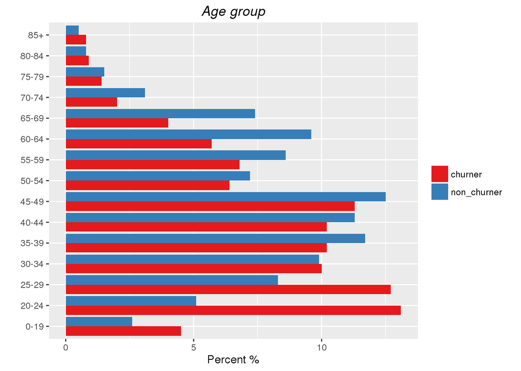

## 3.2 Customer Status

We observe changes in the customer status variable compared with the initial population.

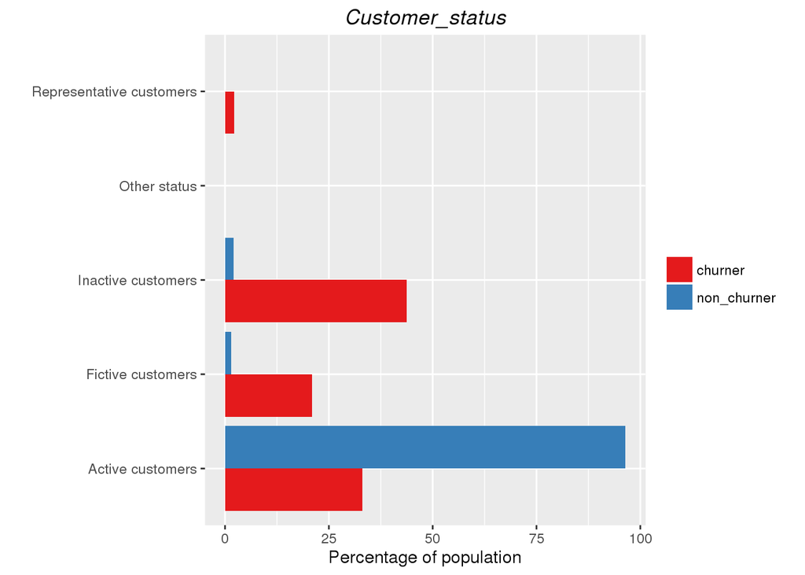

## 3.3 Employment type

The employment type variable, while not significantlly discriminant, appears to show that *churners are slightly less attached to an employer and have a more independent streak or are simply unemployed*.

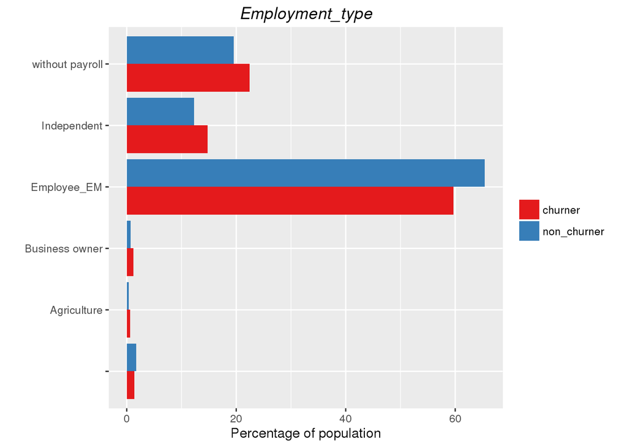

## 3.4 Occupation

The occupation variable has kept the same distribution as with the previous population.

Probably to some extent correlated with the age group, this dimension of the data shows that *churners are more likly to be students or unemployed, and less likly to be pensioners*.

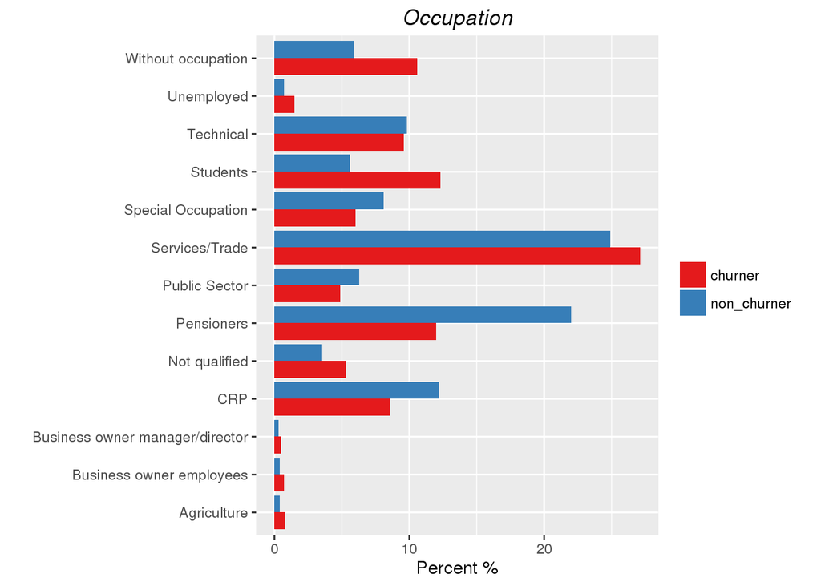

## 3.5 Marketing Segment

The marketing segment variable has kept the same distribution as with the previous population.

In particular, we can notice that churners are less concentrated in the mass customers with potential category. As per BRD`s explination, this is an IBFS category that classifies clients on quantitative and qualitative criteria such as: assets, income, affiliation with affluent clients.

Hence, we can conclude that *churners are in general a less valuble group of clients*.

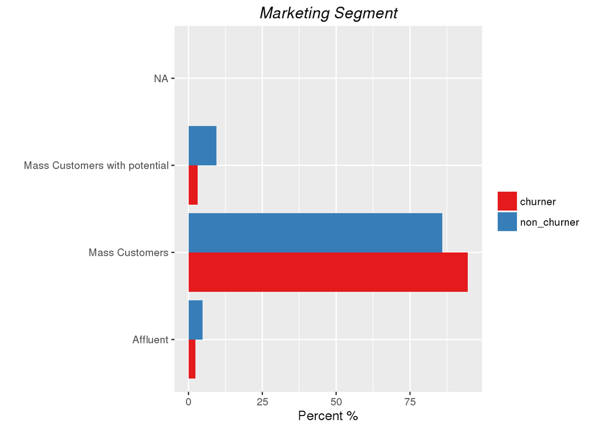

## 3.6 Marital status

The marital status variable has kept the same distribution as with the previous population.

We observe a higher concentration of the non - churner clients within the married category, and vice-versa, which means that *churners are in general less stable clients*.

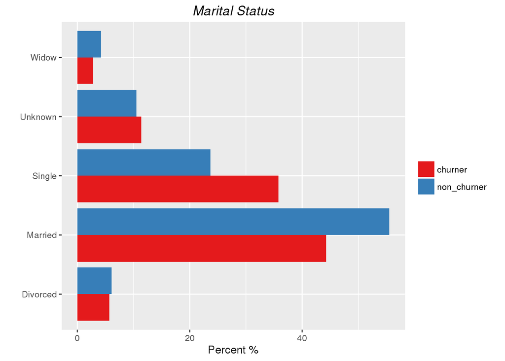

## 3.7 Region

The region, which is a geographic dimension of the branch managed variable, appears to be slightly discriminant in certain areas.

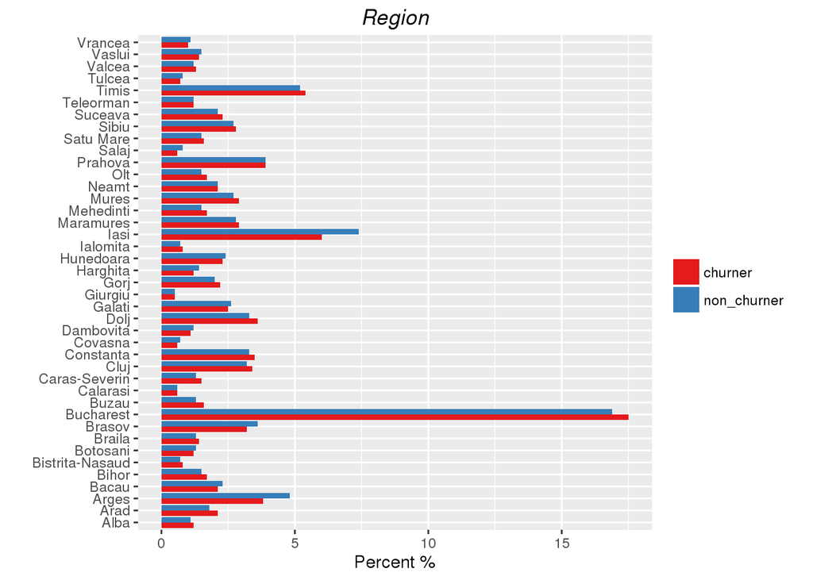

## 3.8 Choropleth: Geo-spatial distribution

In continuation of the previous plot, we craete a choropleth map to visualize the geographical distribution of the churner and non - churner clients.

**To compare the regions with different population size, we ploted the distribution on the percentage of the respective group from the regions total distribution**. Hence, the non churner population varies between 95% and upwards, while the churner population varies between 5% and below.

On the map below we notice few regions in central and eastren Romania with higher concetnration of non churner clients.

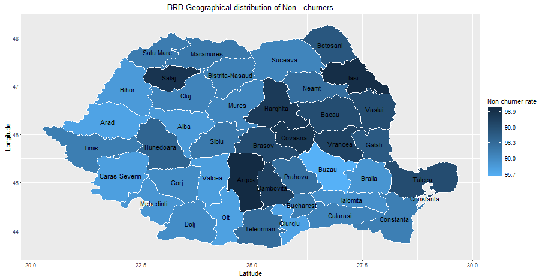

However, **please note that the repartition is based on one or couple of percentage points difference**, so it is unclear to what extent it could predict the churner behavior.

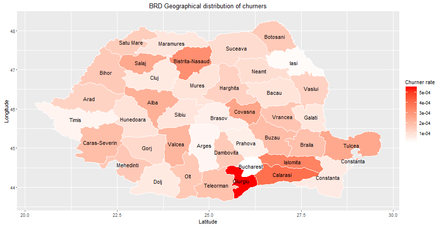

## 3.9 Calendar Heatmap: Seniority

In the initial population, the seniority represented a variable with significant discrepancy between the churner and non churner population.

In line with the previous research BRD has conducted, we can observe again that the *churners have a high concentration of entry few months prior to the churn reference date*.

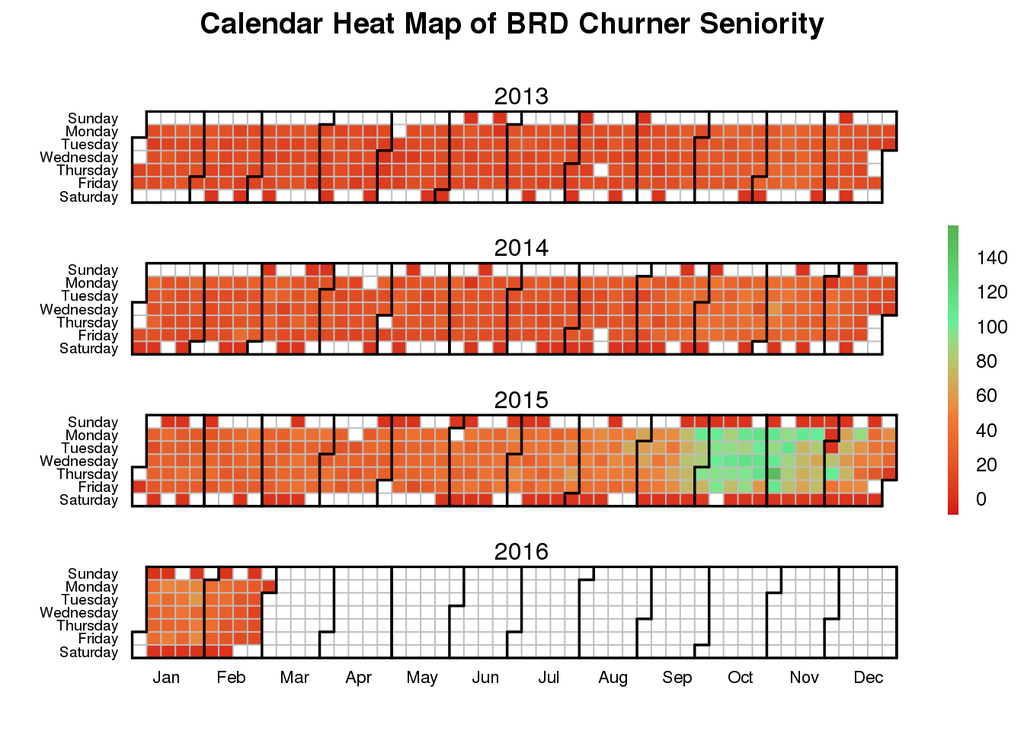

While in the non churner population we observe also a high concentration of the clients with entry dates prior to the churn reference date, the *seniority in this case has a more normal distribution*.

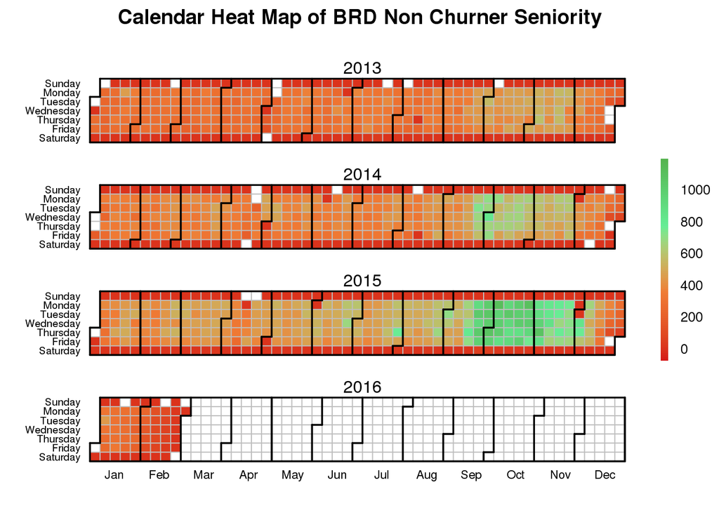

We observe that with the new population the number decreased to 14% from the initial 20%.

```r
NROW(filter(client_mash_database, is_churner == 1 & seniority_months < 6)) / NROW(filter(client_mash_database, is_churner == 1 & seniority_months > 6)) * 100
```

```
## [1] 14.75
```

Nevertheless, the non churner population retains a far smaller concentration of clients with entry dates at 4%.

```r
NROW(filter(client_mash_database, is_churner == 0 & seniority_months < 6)) / NROW(filter(client_mash_database, is_churner == 0 & seniority_months > 6)) * 100
```

```
## [1] 4.601461
```

## 3.10 Sum incomes

Next, we will check the repartition for the sum of incomes between the different populations.

We see on the plot that the **non churners have higher distribution above 2500 RON**. And especially higher above 4000 RON.

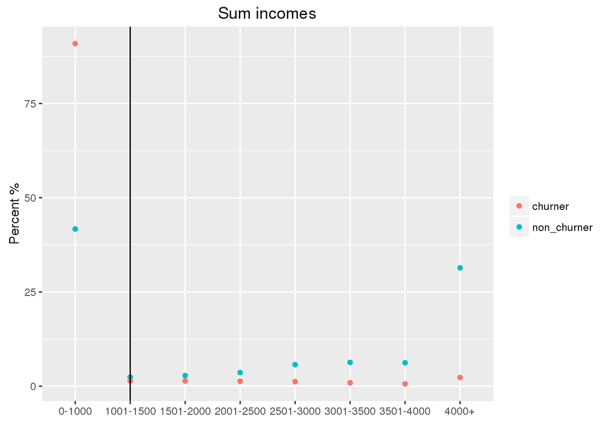

## 3.11 Salary convention

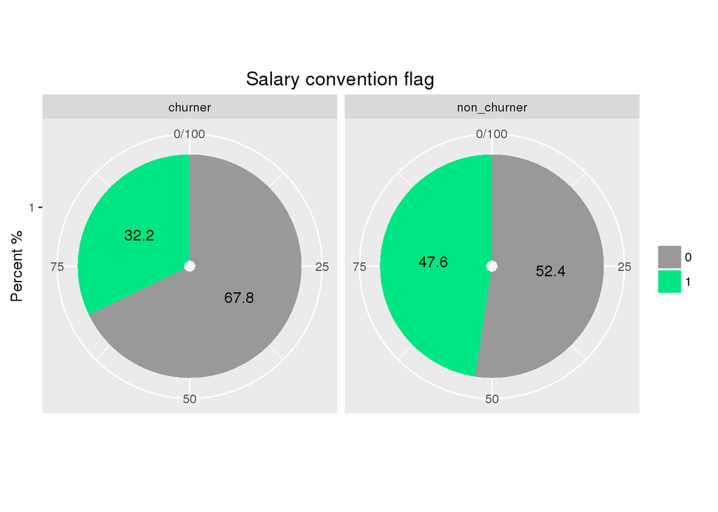

## 3.12 Pension convention

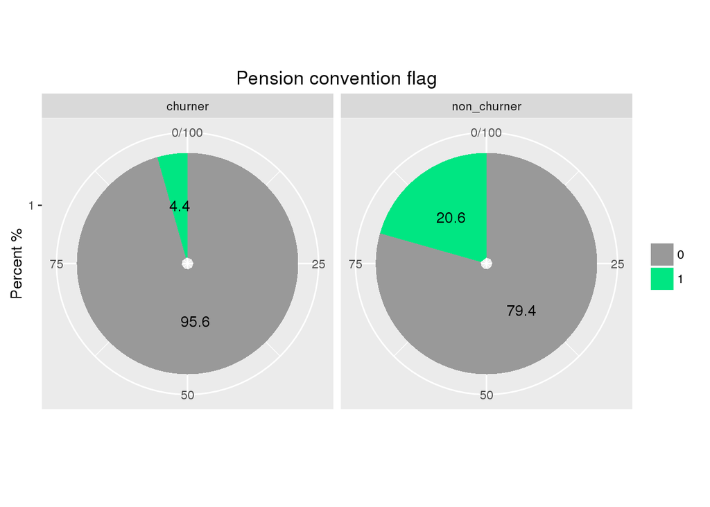

## 3.13 Student convention

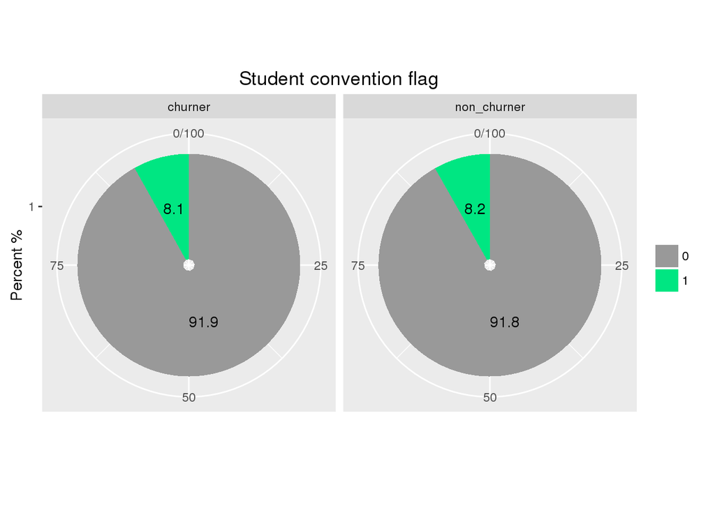